# Presentation of Shiny

## Setup Shiny

## Shiny generals

- Shiny is an R package that makes it easy to build interactive web applications (apps) straight from R.
- Shiny applications will run on a server.
- They will hosted right on your computer over an integrated service.
- With this apps you can create interactive web applications for data visialization.

## requirements

- tidyverse
- shiny
- shinythemes
- We need a package called owmr for getting our data from the openweather API.
- Account for API (in this case: https://openweathermap.org/api)
- Set up your API

### Install OWMR and shiny

```r
#install.packages("owmr")
#install.packages("shiny")
#install.packages("shinythemes")
```

### Run library

### Set up your api key

There are two ways to setup your API.

```r
#1.  owmr_settings("Your API Key")

#2. store it in an environment variable called OWM_API_KEY (recommended)

#Sys.setenv(OWM_API_KEY = "Your API Key") # if not set globally
```

## Download some data

- With the get_current function we will get a tibble with current weather data
- from the city
- with the time of running.

```r
#(current_weather <- get_current("Kiel", units = "metric") %>%
#  owmr_as_tibble()) %>% names()
```

- With the get_forecast function we will get a forecast

```r
#forecast <- get_forecast("Kiel", units = "metric") %>%
#  owmr_as_tibble()
```

## Save the Data

```r
#write_rds(forecast, "my_forecast.Rds")
my_forecast <- read_rds("my_forecast.Rds")
```

## Analyse the data

## View the data

```r
#View(current_weather)
#View(forecast)

class(my_forecast)
```

```
## [1] "tbl_df"     "tbl"        "data.frame"
```

```r
str(my_forecast)
```

```
## Classes 'tbl_df', 'tbl' and 'data.frame':    40 obs. of  19 variables:
##  $ dt_txt             : chr  "2019-10-28 15:00:00" "2019-10-28 18:00:00" "2019-10-28 21:00:00" "2019-10-29 00:00:00" ...
##  $ temp               : num  9.94 7.11 6.09 5.24 4.92 7.58 8.57 9.42 8.95 7.01 ...
##  $ pressure           : num  1018 1020 1020 1021 1021 ...
##  $ humidity           : num  74 79 80 83 87 71 61 57 63 66 ...
##  $ temp_min           : num  9.83 7.03 6.03 5.21 4.92 7.58 8.57 9.42 8.95 7.01 ...
##  $ temp_max           : num  9.94 7.11 6.09 5.24 4.92 7.58 8.57 9.42 8.95 7.01 ...
##  $ weather_id         : num  500 802 800 800 800 801 800 800 500 803 ...
##  $ weather_main       : chr  "Rain" "Clouds" "Clear" "Clear" ...
##  $ weather_description: chr  "light rain" "scattered clouds" "clear sky" "clear sky" ...
##  $ weather_icon       : chr  "10d" "03n" "01n" "01n" ...
##  $ wind_speed         : num  5.06 4.67 3.56 2.65 3.02 6.1 6.25 4.59 4.09 4.56 ...
##  $ wind_deg           : num  306 309 302 278 333 42 50 45 26 28 ...
##  $ clouds_all         : num  72 35 0 0 0 17 1 1 71 55 ...
##  $ dt                 : int  1572274800 1572285600 1572296400 1572307200 1572318000 1572328800 1572339600 1572350400 1572361200 1572372000 ...
##  $ sea_level          : int  1018 1020 1020 1021 1021 1024 1026 1028 1028 1030 ...
##  $ grnd_level         : int  1017 1019 1019 1020 1020 1022 1025 1026 1027 1029 ...
##  $ temp_kf            : num  0.11 0.08 0.06 0.03 0 0 0 0 0 0 ...
##  $ rain_3h            : num  0.44 NA NA NA NA NA NA NA 0.06 NA ...
##  $ sys_pod            : chr  "d" "n" "n" "n" ...
```

Because we have only one row in the current_weather tibble we choose the forecast tibble.

## Preparing the data

Because the timestamp is saved as a character we cant use it well. So we could use the Lubridate package to convert the character timestamp to a datetime.

```r
#install.packages("lubridate")
library(lubridate)
my_forecast$dt_txt <- ymd_hms(my_forecast$dt_txt)
```

## How many hours we have?

We should view the data with some funktions to see how many hours and how many rows and attributes of forecast we got.

- 40 rows of data. So we got 39*3h= 117h = 4.875 d of time in 40 rows.
- 19 variables

## Lets plot some graphics

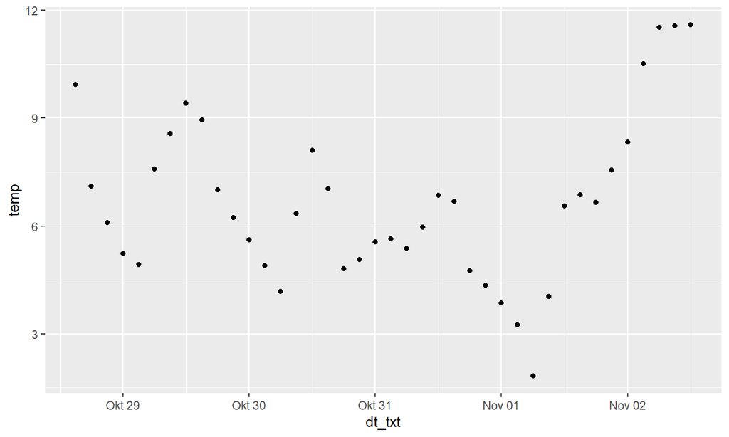

```r
ggplot(my_forecast) +
  geom_point(aes(dt_txt, temp))
```

We should try a shiny app.

## Do some Shiny stuff

## Therefore we need a app template

Because we are here in a markdown file we have to use some other stuff called inline applications

## Some simple app with a slider input

```r
shinyApp(
  ui = fluidPage(
        sliderInput(inputId = "num",
                label = "Choose a number",
                value = 50, min = 1, max = 100),
        plotOutput("hist")

   ),



  server = function(input, output) {
    output$hist <- renderPlot({
      title <- "Normalverteilung"
      hist(rnorm(input$num), main = title)
    })
  },

  options = list(height = 500)
)
```

Shiny applications not supported in static R Markdown documents

## Interaktive histogram

```r
shinyApp(
  ui <- fluidPage(

  # App title ----
  titlePanel("First app!"),

  # Sidebar layout with input and output definitions ----
  sidebarLayout(

    # Sidebar panel for inputs ----
    sidebarPanel(

      # Input: Slider for the number of bins ----
      sliderInput(inputId = "bins",
                  label = "Number of bins:",
                  min = 1,
                  max = 50,
                  value = 30)

    ),

    # Main panel for displaying outputs ----
    mainPanel(

      # Output: Histogram ----
      plotOutput(outputId = "distPlot")

    )
  )
),
server <- function(input, output) {

  # Histogram of the Old Faithful Geyser Data ----
  # with requested number of bins
  # This expression that generates a histogram is wrapped in a call
  # to renderPlot to indicate that:
  #
  # 1. It is "reactive" and therefore should be automatically
  #    re-executed when inputs (input$bins) change
  # 2. Its output type is a plot
  output$distPlot <- renderPlot({

    x    <- faithful$waiting
    bins <- seq(min(x), max(x), length.out = input$bins + 1)

    hist(x, breaks = bins, col = "#75AADB", border = "white",
         xlab = "Waiting time to next eruption (in mins)",
         main = "Histogram of waiting times")

    })

}
)
```

Shiny applications not supported in static R Markdown documents

## Show data in a table

```r
shinyApp(
 ui <- fluidPage(

  # App title ----
  titlePanel("Shiny Text"),

  # Sidebar layout with a input and output definitions ----
  sidebarLayout(

    # Sidebar panel for inputs ----
    sidebarPanel(

      # Input: Selector for choosing dataset ----
      selectInput(inputId = "dataset",
                  label = "Choose a dataset:",
                  choices = c("forecast")),

      # Input: Numeric entry for number of obs to view ----
      numericInput(inputId = "obs",
                   label = "Number of observations to view:",
                   value = 10)
    ),

    # Main panel for displaying outputs ----
    mainPanel(

      # Output: Verbatim text for data summary ----
      verbatimTextOutput("summary"),

      # Output: HTML table with requested number of observations ----
      tableOutput("view")

    )
  )
),

# Define server logic to summarize and view selected dataset ----
server <- function(input, output) {

  # Return the requested dataset ----
  datasetInput <- reactive({
    switch(input$dataset,
           "forecast" = my_forecast)
  })

  # Generate a summary of the dataset ----
  output$summary <- renderPrint({
    dataset <- datasetInput()
    summary(dataset)
  })

  # Show the first "n" observations ----
  output$view <- renderTable({
    head(datasetInput(), n = input$obs)
  })

}
)
```

Shiny applications not supported in static R Markdown documents

## Some interactive plot with our dataset

```r
shinyApp(
  ui <- fluidPage(
    #App title
    titlePanel("Test App"),

    #Sidebar Layout
    sidebarLayout(
      sidebarPanel(
        selectInput(inputId = "variable",
                    label = "Was möchten sie sehen?",
                    choices = colnames(my_forecast)
                    )
      ),
      mainPanel(
        plotOutput(outputId = "dia"),
        tableOutput(outputId = "table")
      )

      )
    ),
  server <- function(input, output){

    variableInput <- reactive({
      switch(input$variable,
             "temp" = my_forecast$temp,
             "pressure" = my_forecast$pressure,
             "humidity" = my_forecast$humidity,
             "temp_min" = my_forecast$temp_min,
             "temp_max" = my_forecast$temp_max,
             "weather_id" = my_forecast$weather_id,
             "weather_main" = my_forecast$weather_main,
             "weather_description" = my_forecast$weather_description,
             "weather_icon" = my_forecast$weather_icon,
             "wind_speed" = my_forecast$wind_speed,
             "wind_deg" = my_forecast$wind_deg,
             "clouds_all" = my_forecast$clouds_all,
             "dt" = my_forecast$dt,
             "sea_level" = my_forecast$sea_level,
             "grnd_level" = my_forecast$grnd_level,
             "temp_kf" = my_forecast$temp_kf,
             "rain_3h" = my_forecast$rain_3h,
             "sys_pod" = my_forecast$sys_pod,
             "dt_txt" = my_forecast$dt_txt
             )
    })
    tableInput <- reactive({
      df <- my_forecast %>%
        group_by(weather_main)


    })
    output$dia <- renderPlot({
      ggplot(my_forecast, aes(x = dt_txt, y = variableInput()))+
        geom_point()
    })
    output$table <- renderTable({
      my_forecast
    })
  }

)
```

Shiny applications not supported in static R Markdown documents

## Source

1. (https://shiny.rstudio.com/)
2. (https://shiny.rstudio.com/images/shiny-cheatsheet.pdf)
3. (https://shiny.rstudio.com/tutorial/)
4. (https://crazycapivara.github.io/owmr/)